# Lesson140 · Defend a two-task RDL reproduction

Teacher solution · PROVIDED: inspect/run; TODO: implement; CHECK: run unchanged; EXIT: defend. Tier B: complete released relational task evidence. Default CPU execution audits artifacts; the post-EXIT GPU gate trains fresh models.

## Concept recap

A query is an entity at a cutoff; a prediction must retain both coordinates. Validation chooses weights; test evaluates the frozen choice. A reproduction report asks separately whether all planned runs finished, whether their metric is close, and whether the available protocol evidence matches.

Worked example: validation [.70,.75,.75] chooses epoch2 even when epoch3 has a better test score. A report with only seeds0–3 cannot summarize a planned five-seed result. With all five present, a close score still cannot repair a changed training population.

The default evidence was generated by the author in fresh L140 runs. Your live functions select, align and judge those artifacts; default execution is not fresh training or proof of mastery.

```python
# @colab-bootstrap — this notebook contains all lesson code and evidence.
import os,sys,subprocess
os.environ.update(OMP_NUM_THREADS='1',OPENBLAS_NUM_THREADS='1',MKL_NUM_THREADS='1')
# Colab's default Torch can execute the small fixture. Full reproduction requires
# the exact pinned runtime documented in l140-reproduction.md, plus host RAM.
if 'google.colab' in sys.modules:
    subprocess.check_call([sys.executable,'-m','pip','install','-q','pytorch-frame==0.2.3','torch-geometric==2.6.1','relbench==1.1.0','sentence-transformers==3.3.1'])
from pathlib import Path
import base64,hashlib,io,json,zlib
import numpy as np
import pandas as pd
from IPython.display import display
RUN_FULL_REPRODUCTION=False
FULL_TASKS=['amazon','trial'];FULL_SEEDS=list(range(5))
PREPARED_ROOTS={}  # Empty means full fresh materialization; reuse only verified directories.
```

```python
# PROVIDED: tie-aware rank arithmetic
def rank_auc(target,scores):
    """Positive-negative concordance with half credit for ties; O(n log n)."""
    y=np.asarray(target);s=np.asarray(scores,dtype=float)
    if y.ndim!=1 or s.shape!=y.shape or not np.isfinite(s).all() or not np.isin(y,[0,1]).all():
        raise ValueError('Aligned binary labels and finite scores required')
    positives=int(y.sum());negatives=len(y)-positives
    if positives==0 or negatives==0:raise ValueError('Both classes required')
    order=np.argsort(s,kind='stable');s=s[order];y=y[order]
    starts=np.r_[0,1+np.flatnonzero(s[1:]!=s[:-1])];ends=np.r_[starts[1:],len(s)]
    group_pos=np.add.reduceat(y,starts);group_neg=ends-starts-group_pos
    lower_neg=np.cumsum(group_neg)-group_neg
    return float(np.sum(group_pos*(lower_neg+.5*group_neg))/(positives*negatives))
```

A checkpoint in reasoning, not just in training

**Reading route.** Freeze the two recipes → select using validation → align keys → defend three separate verdicts.

**Quick prerequisite reminder**

A hyperparameter is a setting chosen outside gradient updates, such as learning rate or neighbor fanout. A percentage point is an absolute difference between percentages: 70% to 71% is one point. Sample SD describes spread among runs; it does not measure uncertainty across databases.

## 1 · Turn two scores into a defensible result

Lessons [138](https://avistian.github.io/relational/lessons/0138-ecommerce-amazon.html) and [139](https://avistian.github.io/relational/lessons/0139-healthcare-trial.html) established two domain pipelines. They left a harder question: **what evidence lets you say that you reproduced a baseline?** A plausible score can survive a broken join, a missing seed, a changed population, or test-driven selection. This checkpoint asks you to defend the entire chain.

Your tangible win is a two-task report whose claims can be regenerated from query identities, checkpoint histories and saved predictions. Allow 25 minutes for the core lesson and a separate lab/defense session. Read [RelBench v1 Table 6 and Appendix B.2](https://arxiv.org/html/2407.20060v1#A2.SS1); compare the source configuration before looking at scores.

## 2 · Freeze two contracts before training

A common model does not imply identical hyperparameters or identical query semantics. Preserve each task's released recipe. The comparison is replication against two named baselines, not a controlled experiment about domain difficulty.

| Contract | Amazon user-churn | Trial study-outcome |
| --- | --- | --- |
| Query | Customer and cutoff | Study and cutoff |
| Eligible population | At least one review in the previous 91 days | Started study with a qualifying analysis in the next 365 days |
| Positive | No review in the next 91 days | Minimum qualifying primary p-value ≤ .05 |
| Neighbor aggregation | Sum | Mean |
| Per-hop fanout | 128, 64 | 64, 32 |
| Adam learning rate | .005 | .0001 |
| Released epochs | 10 | 20 |
| Batch / width / layers | 512 / 128 / 2 | 512 / 128 / 2 |
| Selection | First maximum validation AUROC | First maximum validation AUROC |

Five new runs per task use seeds 0–4. Binary cross-entropy trains both. A released epoch stops after `steps > 2000`, so Amazon uses **2,001 batches per epoch**, not a complete pass through its 4,708,383 training queries. “Full data” means the full released population is available; it does not mean visiting every row in every epoch. Trial visits all 11,994 training queries each epoch. [Released trainer](https://avistian.github.io/relational/labs/sources/l139/examples__gnn_node.py)

The source pin is `9aa346267c2e1c560bd92da07d6f4ad1ca2f0639`. Preprocessing uses the full test-cutoff database snapshot, the released feature-type inference and pinned GloVe text features. We reuse checksum-verified materializations; we initialize and train new weights. The [complete trainer](https://avistian.github.io/relational/labs/_full_l140.py) and [model implementation](https://avistian.github.io/relational/labs/relkit/rdl_l117.py) are visible in the notebook, alongside a fresh-materialization path.

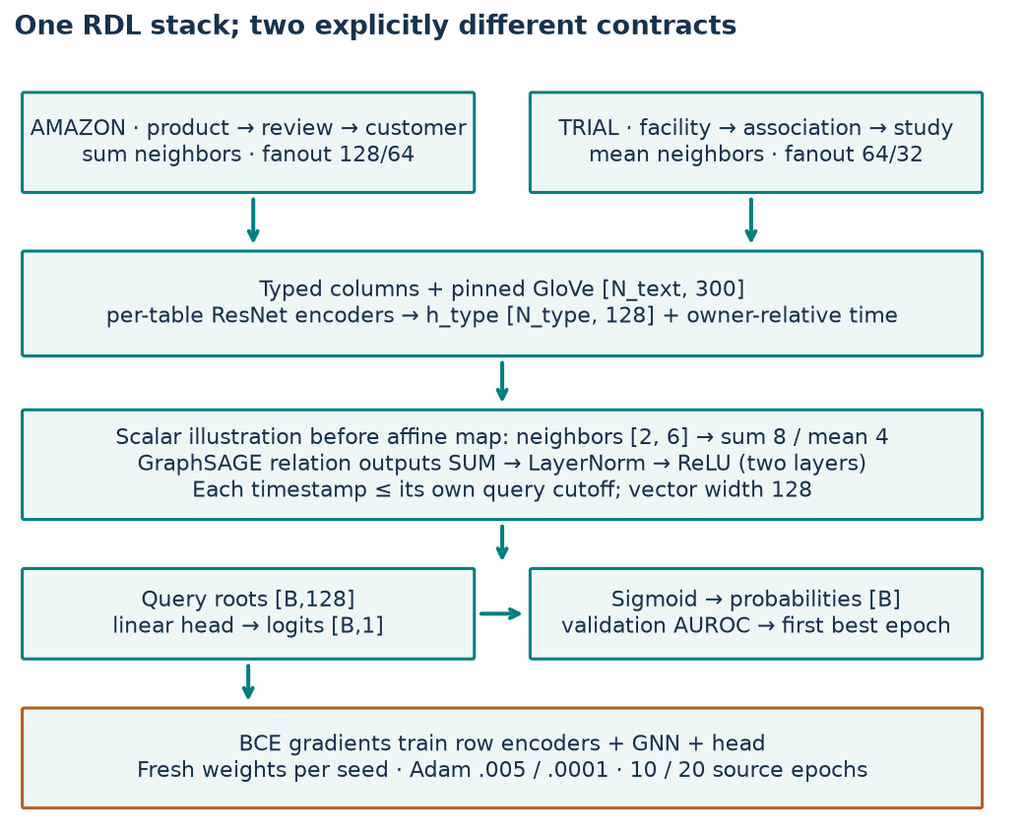

Two concrete relational paths share the encoder → temporal GNN → head computation. The scalar neighbor example is illustrative. Task-specific fanout, aggregation and optimizer settings remain distinct. Scroll horizontally on a narrow screen.

Trace one facility → association → study path. Each table's row encoder produces 128 channels; the query owner's time encoding is added; relation-specific GraphSAGE outputs are summed and normalized within each layer. The study root reaches the linear head after two layers. A customer → review → product path uses the same stack with the Amazon recipe. We transfer program structure, not learned weights.

## 3 · Freeze the checkpoint using validation only

The best training loss is not the checkpoint rule. The best test score is not the checkpoint rule either. Record every epoch, then select the **first** strict maximum validation AUROC. A later tie must keep the earlier epoch. Re-evaluating the selected weights may draw new sampled neighborhoods; its validation score can differ from the selection score.

**Predict:** validation scores are .70, .75, .75; test scores are .90, .60, 1.00. Which epoch must survive? Commit before changing the selector.

Synthetic baseline: epoch2 wins; epoch3 ties validation and must not replace it.

**TODO 1 — `select_checkpoint(history)`.** Require a complete ordered history with finite validation AUROCs. Return the epoch under the frozen rule. The CHECK rejects choosing by test, taking the last tie, skipping epochs or accepting NaN. Use your function on every fresh author history.

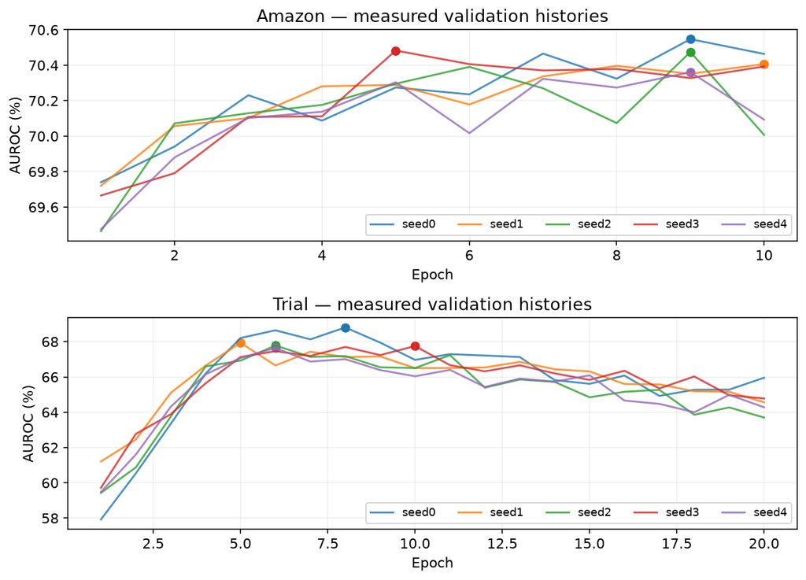

Fresh measured validation curves for every seed. Dots mark first maxima; no test curve is used for selection. Scroll horizontally on a narrow screen.

We do not rerun “unlucky” seeds or retune after reading the test table. The same public test sets appeared in earlier lessons; these runs are fresh training, not new pristine holdouts. They support a replication exercise, not a new confirmatory discovery.

```python
# SOLUTION
def select_checkpoint(history):
    """Return the first epoch with maximum finite validation AUROC."""
    if not history or [r['epoch'] for r in history] != list(range(1,len(history)+1)):
        raise ValueError('Require complete, ordered epochs starting at one')
    values=np.asarray([r['val']['roc_auc'] for r in history],dtype=float)
    if not np.isfinite(values).all() or ((values<0)|(values>1)).any():
        raise ValueError('Invalid validation AUROC')
    return history[int(np.argmax(values))]['epoch']
```

```python
# CHECK
def check_selection(fn):
    h=[{'epoch':1,'val':{'roc_auc':.70},'test':.9},{'epoch':2,'val':{'roc_auc':.75},'test':.6},{'epoch':3,'val':{'roc_auc':.75},'test':1.0}]
    assert fn(h)==2, 'Use the first validation maximum; test is irrelevant'
    for bad in [[],[{'epoch':1,'val':{'roc_auc':float('nan')}}],h[:1]+h[:1]]:
        try:fn(bad)
        except ValueError:pass
        else:raise AssertionError('Reject empty, nonfinite or duplicated histories')
check_selection(select_checkpoint)
print("PASS: select_checkpoint")
```

```
PASS: select_checkpoint
```

```python
selected=[]
for task,seeds in HISTORIES.items():
    for seed,history in seeds.items():
        epoch=select_checkpoint(history)
        assert epoch==1+int(np.argmax([r['val']['roc_auc'] for r in history]))
        selected.append(dict(task=task,seed=int(seed),epoch=epoch,selection_auc=history[epoch-1]['val']['roc_auc']))
display(pd.DataFrame(selected))
```

|  | task | seed | epoch | selection_auc |
| --- | --- | --- | --- | --- |
| 0 | amazon | 0 | 9 | 0.705473 |
| 1 | amazon | 1 | 10 | 0.704065 |
| 2 | amazon | 2 | 9 | 0.704749 |
| 3 | amazon | 3 | 5 | 0.704830 |
| 4 | amazon | 4 | 9 | 0.703609 |
| 5 | trial | 0 | 8 | 0.688057 |
| 6 | trial | 1 | 5 | 0.679341 |
| 7 | trial | 2 | 6 | 0.677818 |
| 8 | trial | 3 | 10 | 0.677500 |
| 9 | trial | 4 | 6 | 0.676406 |

## 4 · Score the right query, not the current row position

Suppose queries arrive as `(entity 4, day10)`, `(entity 4, day20)`, `(entity 8, day10)`, but predictions arrive in reverse order. A positional zip evaluates a different claim. Joining on entity alone also merges two distinct forecasts. Require unique **(entity, cutoff)** keys on both sides, equal populations, and finite probabilities before aligning.

**TODO 2 — `align_predictions(query_keys, prediction_keys, predictions)`.** Return probabilities in canonical query order. Missing, duplicate, unexpected or nonfinite predictions must fail. The lab shuffles real prediction rows and checks that the AUROC stays unchanged. Your output feeds the scorer; it is not an unused exercise beside a hidden answer.

AUROC measures positive–negative ordering, with half credit for ties. The portable notebook provides the rank implementation and verifies it against scikit-learn. No threshold or calibration claim follows from AUROC alone.

Temporal correctness is a separate audit: every sampled timestamp must be at or before **its owning query cutoff**, at every hop. Untimestamped metadata and inferred trial timestamps still lack historical arrival/version records. Passing the released sampler audit does not prove prospective availability. [Trial timestamp construction](https://avistian.github.io/relational/labs/sources/l139/relbench__datasets__trial.py) · [Amazon audit](https://avistian.github.io/relational/labs/l138-reproduction.md)

```python
# SOLUTION
def align_predictions(query_keys, prediction_keys, predictions):
    """Return probabilities in query order; require identical unique key sets."""
    query_keys=list(map(tuple,query_keys));prediction_keys=list(map(tuple,prediction_keys))
    p=np.asarray(predictions,dtype=float)
    if p.ndim!=1 or len(p)!=len(prediction_keys) or not np.isfinite(p).all() or ((p<0)|(p>1)).any():
        raise ValueError('Invalid probability vector')
    if len(set(query_keys))!=len(query_keys) or len(set(prediction_keys))!=len(prediction_keys):
        raise ValueError('Duplicate entity/cutoff key')
    if set(query_keys)!=set(prediction_keys):raise ValueError('Prediction and query populations differ')
    lookup=dict(zip(prediction_keys,p))
    return np.asarray([lookup[key] for key in query_keys])
```

```python
# CHECK
def check_alignment(fn):
    q=[(4,10),(4,20),(8,10)]
    assert np.array_equal(fn(q,[q[2],q[0],q[1]],[.2,.9,.4]),[.9,.4,.2]), 'Entity alone is not a query key'
    for keys,values in [(q[:2],[.1,.2]),([q[0],q[0],q[2]],[.1,.2,.3]),(q,[.1,float('nan'),.3]),(q+[q[0]],[.1,.2,.3,.4])]:
        try:fn(q,keys,values)
        except ValueError:pass
        else:raise AssertionError('Missing, duplicate, extra or invalid predictions accepted')
check_alignment(align_predictions)
print("PASS: align_predictions")
```

```
PASS: align_predictions
```

```python
rows=[];rng=np.random.default_rng(140)
from sklearn.metrics import roc_auc_score
for task in ['amazon','trial']:
    for split in ['val','test']:
        prefix=f'{task}_{split}_'
        keys=list(zip(DATA[prefix+'entity'],DATA[prefix+'time']))
        target=DATA[prefix+'target'];order=rng.permutation(len(keys))
        for seed in range(5):
            pred=align_predictions(keys,[keys[i] for i in order],DATA[prefix+f's{seed}'][order])
            score=rank_auc(target,pred)
            assert abs(score-roc_auc_score(target,pred))<1e-12
            rows.append(dict(task=task,split=split,seed=seed,auc=score,queries=len(keys)))
display(pd.DataFrame(rows));print('All real prediction vectors shuffled, aligned and independently scored')
```

|  | task | split | seed | auc | queries |
| --- | --- | --- | --- | --- | --- |
| 0 | amazon | val | 0 | 0.705476 | 409792 |
| 1 | amazon | val | 1 | 0.704067 | 409792 |
| 2 | amazon | val | 2 | 0.704753 | 409792 |
| 3 | amazon | val | 3 | 0.704830 | 409792 |
| 4 | amazon | val | 4 | 0.703609 | 409792 |
| 5 | amazon | test | 0 | 0.705240 | 351885 |
| 6 | amazon | test | 1 | 0.701509 | 351885 |
| 7 | amazon | test | 2 | 0.703764 | 351885 |
| 8 | amazon | test | 3 | 0.703258 | 351885 |
| 9 | amazon | test | 4 | 0.703009 | 351885 |
| 10 | trial | val | 0 | 0.687686 | 960 |
| 11 | trial | val | 1 | 0.679149 | 960 |
| 12 | trial | val | 2 | 0.677465 | 960 |
| 13 | trial | val | 3 | 0.677862 | 960 |
| 14 | trial | val | 4 | 0.676437 | 960 |
| 15 | trial | test | 0 | 0.678641 | 825 |
| 16 | trial | test | 1 | 0.693376 | 825 |
| 17 | trial | test | 2 | 0.694266 | 825 |
| 18 | trial | test | 3 | 0.681087 | 825 |
| 19 | trial | test | 4 | 0.684519 | 825 |

```
All real prediction vectors shuffled, aligned and independently scored
```

## 5 · Keep three verdicts instead of one green badge

1. **Execution:** did every planned seed finish the released protocol?
2. **Numerical agreement:** is the mean within the predeclared ±1 percentage point band?
3. **Protocol evidence:** do the available source/data records align, and what remains missing?

These questions can have different answers. For Amazon, the archived training table has **24,172 fewer queries** than paper Table 2; held-out counts match. A close AUROC cannot repair that difference. Clinical archive counts agree, but historical RNG/environment identity remains unestablished on both tasks. [Count evidence](https://avistian.github.io/relational/labs/evidence/l138/paper_alignment.json)

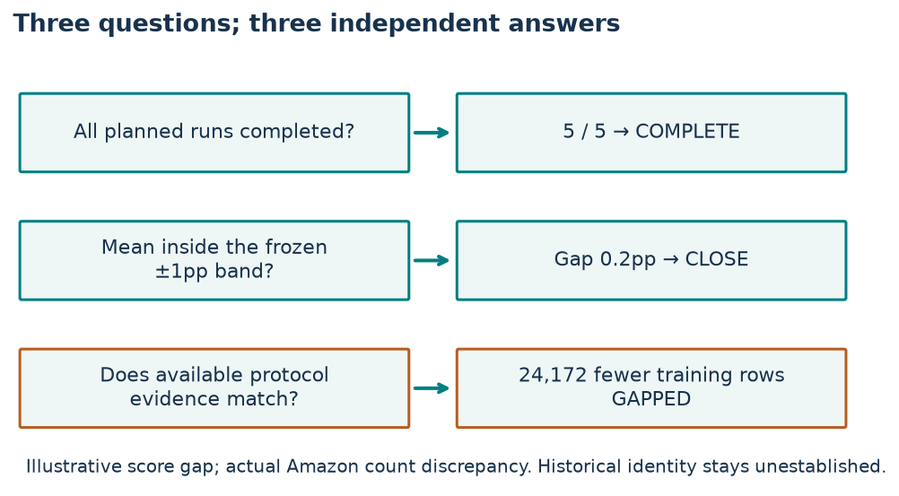

Three evidence gates. The 0.2pp gap is illustrative; the Amazon training-count discrepancy is real. Scroll horizontally on a narrow screen.

**Predict:** four of five runs finish, all close to the paper. May their mean qualify the planned experiment? Then suppose all five finish but the archive differs. Which verdict changes?

Hypothetical baseline:5/5 seeds,0.2pp gap,archive mismatch → COMPLETE / CLOSE / GAPPED; historical identity NOT_ESTABLISHED.

**TODO 3 — `reproduction_verdict(...)`.** Require exactly the planned seed set before producing a mean or closeness verdict. Report sample SD (`ddof=1`) and a separate protocol status. A missing seed yields `INCOMPLETE` and `NOT_EVALUATED`, not an average of the convenient survivors. Reject unexpected seeds and invalid scores.

The ±1pp rule is a **descriptive comparison**, not a statistical equivalence test. Seed SD measures variation from this training procedure conditional on this split and preprocessing. It is neither a confidence interval over future deployments nor a cross-database uncertainty estimate. Seed0 on Amazon and seed0 on trial are unrelated runs, not paired observations for a cross-domain test. Two tasks also do not establish general RDL superiority.

```python
# SOLUTION
def reproduction_verdict(values, expected_seeds, target, tolerance, protocol_match):
    """Separate execution completeness, numerical agreement and protocol evidence."""
    expected=list(expected_seeds)
    if len(expected)<2 or len(set(expected))!=len(expected):raise ValueError('Require at least two unique seeds')
    if not set(values)<=set(expected):raise ValueError('Unexpected seed')
    a=np.asarray(list(values.values()),dtype=float)
    if not np.isfinite(a).all() or ((a<0)|(a>1)).any():raise ValueError('Invalid seed AUROC')
    if not np.isfinite(target) or not 0<=target<=1 or not np.isfinite(tolerance) or tolerance<0:raise ValueError('Invalid comparison')
    complete=set(values)==set(expected)
    mean=float(np.mean(a)) if complete else None
    # Eight machine epsilons protect an inclusive decimal boundary; no metric-scale slack.
    rounding=8*np.finfo(float).eps
    return dict(execution='COMPLETE' if complete else 'INCOMPLETE',mean=mean,
                sample_sd=float(np.std(a,ddof=1)) if complete else None,
                score=('CLOSE' if abs(mean-target)<=tolerance+rounding else 'OUTSIDE_TOLERANCE') if complete else 'NOT_EVALUATED',
                protocol='ALIGNED_WITH_RELEASE' if protocol_match else 'GAPPED',
                historical_identity='NOT_ESTABLISHED')
```

```python
# CHECK
def check_verdict(fn):
    result=fn({0:.69,1:.71},[0,1],.70,.01,False)
    assert result['execution']=='COMPLETE' and result['score']=='CLOSE' and result['protocol']=='GAPPED'
    assert result['historical_identity']=='NOT_ESTABLISHED'
    assert abs(result['sample_sd']-np.sqrt(.0002))<1e-12
    r=fn({0:.69},[0,1],.70,.01,True)
    assert r['execution']=='INCOMPLETE' and r['score']=='NOT_EVALUATED' and r['mean'] is None
    assert fn({0:.60,1:.62},[0,1],.70,.01,True)['score']=='OUTSIDE_TOLERANCE'
    assert fn({0:.71,1:.71},[0,1],.70,.01,True)['score']=='CLOSE', 'The declared boundary is inclusive'
    assert fn({0:.71001,1:.71001},[0,1],.70,.01,True)['score']=='OUTSIDE_TOLERANCE'
    for values in [{0:.7,1:float('nan')},{0:.7,1:.7,2:.7}]:
        try:fn(values,[0,1],.70,.01,True)
        except ValueError:pass
        else:raise AssertionError('Invalid or unexpected seed accepted')
check_verdict(reproduction_verdict)
print("PASS: reproduction_verdict")
```

```
PASS: reproduction_verdict
```

```python
verdicts=[]
for task in ['amazon','trial']:
    for split in ['val','test']:
        values={r['seed']:r['auc'] for r in rows if r['task']==task and r['split']==split}
        v=reproduction_verdict(values,list(range(5)),TARGETS[task][split],.01,task!='amazon')
        verdicts.append(dict(task=task,split=split,**v))
display(pd.DataFrame(verdicts))
assert all(v['execution']=='COMPLETE' for v in verdicts)
print('Scores are descriptive. Historical identity remains NOT_ESTABLISHED.')
# Real sampled timestamps retain the owning query cutoff.
node_occurrences=0
for task in ['amazon','trial']:
    for key in DATA.files:
        if key.startswith(task+'_trace_') and key.endswith('_times'):
            owners=DATA[key[:-6]+'_owners'];times=DATA[key]
            assert (times<=DATA[task+'_trace_cutoffs'][owners]).all()
            node_occurrences+=len(times)
print('Independently checked sampled timestamped node occurrences:',node_occurrences)
```

|  | task | split | execution | mean | sample_sd | score | protocol | historical_identity |
| --- | --- | --- | --- | --- | --- | --- | --- | --- |
| 0 | amazon | val | COMPLETE | 0.704547 | 0.000724 | CLOSE | GAPPED | NOT_ESTABLISHED |
| 1 | amazon | test | COMPLETE | 0.703356 | 0.001347 | CLOSE | GAPPED | NOT_ESTABLISHED |
| 2 | trial | val | COMPLETE | 0.679720 | 0.004558 | CLOSE | ALIGNED_WITH_RELEASE | NOT_ESTABLISHED |
| 3 | trial | test | COMPLETE | 0.686378 | 0.007115 | CLOSE | ALIGNED_WITH_RELEASE | NOT_ESTABLISHED |

```
Scores are descriptive. Historical identity remains NOT_ESTABLISHED.
Independently checked sampled timestamped node occurrences: 17601
```

## 6 · Inspect the fresh author evidence

**Predict before revealing:** which task should have wider seed variation? What evidence would make you reject a close mean? Then compare the points, not just the aggregate.

| Task / split | Fresh AUROC % ± sample SD | Paper AUROC % | Score | Protocol |
| --- | --- | --- | --- | --- |
| amazon / val | 70.4547 ± 0.0724 | 70.45 | CLOSE | GAPPED |
| amazon / test | 70.3356 ± 0.1347 | 70.42 | CLOSE | GAPPED |
| trial / val | 67.9720 ± 0.4558 | 68.18 | CLOSE | ALIGNED_WITH_RELEASE |
| trial / test | 68.6378 ± 0.7115 | 68.60 | CLOSE | ALIGNED_WITH_RELEASE |

**Ten fresh full released-protocol fits; 3,817,310 held-out predictions independently rescored.** Amazon protocol remains gapped. Historical identity and whole-paper reproduction: **NOT_ESTABLISHED**.

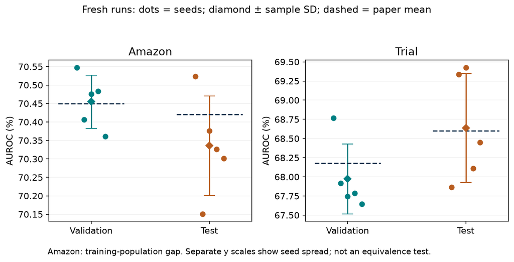

Fresh L140 seed points, means and sample SD. Dashed lines are paper means. Separate vertical scales expose variance; the Amazon protocol gap remains. Scroll horizontally on a narrow screen.

The author report checks all planned runs, full schedules, query keys, original-model checkpoint outputs, independent AUROC arithmetic and recorded temporal audits. Data/label reconstruction from L138/L139 is inherited evidence tied to the same archive hashes; it is not represented as a fresh reconstruction here. [Machine-readable report](https://avistian.github.io/relational/labs/evidence/l140/training.json) · [Protocol, budget and exact commands](https://avistian.github.io/relational/labs/l140-reproduction.md)

The cloud operator reserves each attempt before dispatch. The first complete seed per task doubles as the timing pilot; remaining runs are dispatched only if the forecast fits. The shared cap is **$10 including attempts and validation**, with $3 reserved for overhead. A budget refusal produces an honest incomplete experiment, not an excuse to silently shorten training.

## 7 · Lab and exit defense

[Open the prepared lab](https://avistian.github.io/relational/labs/html/0140-rdl-reproduction-checkpoint.html) · [Student notebook](https://avistian.github.io/relational/labs/0140-rdl-reproduction-checkpoint.ipynb) · [Reference](https://avistian.github.io/relational/reference/rdl-reproduction-checkpoint.html)

Run your three live functions on the portable author evidence. Read and execute the provided small neural forward/backward trace. The full model and trainer are included below the core lab; enabling the fresh-training gate starts a separate experiment and requires the pinned GPU runtime and adequate host RAM. Default notebook execution re-scores artifacts; it does not train ten full models.

Submit a one-page defense with four paragraphs:

- **Contract:** name both targets, populations, splits, source, recipe and seed set; explain why the trial settings differ.
- **Evidence:** report every seed, mean ± sample SD, selected epochs and independently verified query counts.
- **Counter-evidence:** preserve Amazon's count gap, unknown historical availability, sampled evaluation variation, prior test reuse and historical identity limits.
- **Verdict:** state what completed, what is numerically close, and what remains unestablished. Propose one test that could weaken your conclusion.

**Assessment rubric:** contract accuracy, reproducible evidence, treatment of counter-evidence, and defensible scope each earn 0–2 points. Aim for at least 7/8, with no test-based selection, missing-seed averaging, or claim that a close score repairs a data mismatch. A well-supported failed reproduction can pass the learner assessment.

A passing author run is preparation for this assessment. Your checkpoint remains **PENDING_WRITTEN_DEFENSE** until your code and explanation demonstrate the skill. Ask the agent to challenge any unclear claim. Before [Lesson 141’s composite message passing](https://avistian.github.io/relational/lessons/0141-composite-message-passing.html), explain what this baseline does—and why matching it does not prove it uses relational structure optimally.

Write the defense before asking the agent to assess your checkpoint.

**Carry this forward.** The next lesson changes the message itself. Use this checkpoint’s fixed-contract discipline to distinguish a new mechanism from evidence that it helps. [Continue to Lesson 141](https://avistian.github.io/relational/lessons/0141-composite-message-passing.html).

## PROVIDED · full model and graph construction

These are the executed released model primitives, with the unused recommendation-only readout omitted. Read the typed encoders, temporal ownership, relation convolution, root selection and head. MIT source attribution follows. The next cell group reconstructs graph edges and task transforms.

### Column, row and temporal encoders; relation message passing

```python
# The MIT License (MIT)
#
# Copyright (c) 2023 RelBench Team
#
# Permission is hereby granted, free of charge, to any person obtaining a copy
# of this software and associated documentation files (the "Software"), to deal
# in the Software without restriction, including without limitation the rights
# to use, copy, modify, merge, publish, distribute, sublicense, and/or sell
# copies of the Software, and to permit persons to whom the Software is
# furnished to do so, subject to the following conditions:
#
# The above copyright notice and this permission notice shall be included in
# all copies or substantial portions of the Software.
#
# THE SOFTWARE IS PROVIDED "AS IS", WITHOUT WARRANTY OF ANY KIND, EXPRESS OR
# IMPLIED, INCLUDING BUT NOT LIMITED TO THE WARRANTIES OF MERCHANTABILITY,
# FITNESS FOR A PARTICULAR PURPOSE AND NONINFRINGEMENT. IN NO EVENT SHALL THE
# AUTHORS OR COPYRIGHT HOLDERS BE LIABLE FOR ANY CLAIM, DAMAGES OR OTHER
# LIABILITY, WHETHER IN AN ACTION OF CONTRACT, TORT OR OTHERWISE, ARISING FROM,
# OUT OF OR IN CONNECTION WITH THE SOFTWARE OR THE USE OR OTHER DEALINGS IN
# THE SOFTWARE.

from typing import Any, Dict, List, Optional

import torch
import torch_frame
from torch import Tensor
from torch_frame.data.stats import StatType
from torch_frame.nn.models import ResNet
from torch_geometric.nn import HeteroConv, LayerNorm, PositionalEncoding, SAGEConv
from torch_geometric.typing import EdgeType, NodeType


class HeteroEncoder(torch.nn.Module):
    r"""HeteroEncoder based on PyTorch Frame.

    Args:
        channels (int): The output channels for each node type.
        node_to_col_names_dict (Dict[NodeType, Dict[torch_frame.stype, List[str]]]):
            A dictionary mapping from node type to column names dictionary
            compatible to PyTorch Frame.
        torch_frame_model_cls: Model class for PyTorch Frame. The class object
            takes :class:`TensorFrame` object as input and outputs
            :obj:`channels`-dimensional embeddings. Default to
            :class:`torch_frame.nn.ResNet`.
        torch_frame_model_kwargs (Dict[str, Any]): Keyword arguments for
            :class:`torch_frame_model_cls` class. Default keyword argument is
            set specific for :class:`torch_frame.nn.ResNet`. Expect it to
            be changed for different :class:`torch_frame_model_cls`.
        default_stype_encoder_cls_kwargs (Dict[torch_frame.stype, Any]):
            A dictionary mapping from :obj:`torch_frame.stype` object into a
            tuple specifying :class:`torch_frame.nn.StypeEncoder` class and its
            keyword arguments :obj:`kwargs`.
    """

    def __init__(
        self,
        channels: int,
        node_to_col_names_dict: Dict[NodeType, Dict[torch_frame.stype, List[str]]],
        node_to_col_stats: Dict[NodeType, Dict[str, Dict[StatType, Any]]],
        torch_frame_model_cls=ResNet,
        torch_frame_model_kwargs: Dict[str, Any] = {
            "channels": 128,
            "num_layers": 4,
        },
        default_stype_encoder_cls_kwargs: Dict[torch_frame.stype, Any] = {
            torch_frame.categorical: (torch_frame.nn.EmbeddingEncoder, {}),
            torch_frame.numerical: (torch_frame.nn.LinearEncoder, {}),
            torch_frame.multicategorical: (
                torch_frame.nn.MultiCategoricalEmbeddingEncoder,
                {},
            ),
            torch_frame.embedding: (torch_frame.nn.LinearEmbeddingEncoder, {}),
            torch_frame.timestamp: (torch_frame.nn.TimestampEncoder, {}),
        },
    ):
        super().__init__()

        self.encoders = torch.nn.ModuleDict()

        for node_type in node_to_col_names_dict.keys():
            stype_encoder_dict = {
                stype: default_stype_encoder_cls_kwargs[stype][0](
                    **default_stype_encoder_cls_kwargs[stype][1]
                )
                for stype in node_to_col_names_dict[node_type].keys()
            }
            torch_frame_model = torch_frame_model_cls(
                **torch_frame_model_kwargs,
                out_channels=channels,
                col_stats=node_to_col_stats[node_type],
                col_names_dict=node_to_col_names_dict[node_type],
                stype_encoder_dict=stype_encoder_dict,
            )
            self.encoders[node_type] = torch_frame_model

    def reset_parameters(self):
        for encoder in self.encoders.values():
            encoder.reset_parameters()

    def forward(
        self,
        tf_dict: Dict[NodeType, torch_frame.TensorFrame],
    ) -> Dict[NodeType, Tensor]:
        x_dict = {
            node_type: self.encoders[node_type](tf) for node_type, tf in tf_dict.items()
        }
        return x_dict


class HeteroTemporalEncoder(torch.nn.Module):
    def __init__(self, node_types: List[NodeType], channels: int):
        super().__init__()

        self.encoder_dict = torch.nn.ModuleDict(
            {node_type: PositionalEncoding(channels) for node_type in node_types}
        )
        self.lin_dict = torch.nn.ModuleDict(
            {node_type: torch.nn.Linear(channels, channels) for node_type in node_types}
        )

    def reset_parameters(self):
        for encoder in self.encoder_dict.values():
            encoder.reset_parameters()
        for lin in self.lin_dict.values():
            lin.reset_parameters()

    def forward(
        self,
        seed_time: Tensor,
        time_dict: Dict[NodeType, Tensor],
        batch_dict: Dict[NodeType, Tensor],
    ) -> Dict[NodeType, Tensor]:
        out_dict: Dict[NodeType, Tensor] = {}

        for node_type, time in time_dict.items():
            rel_time = seed_time[batch_dict[node_type]] - time
            rel_time = rel_time / (60 * 60 * 24)  # Convert seconds to days.

            x = self.encoder_dict[node_type](rel_time)
            x = self.lin_dict[node_type](x)
            out_dict[node_type] = x

        return out_dict


class HeteroGraphSAGE(torch.nn.Module):
    def __init__(
        self,
        node_types: List[NodeType],
        edge_types: List[EdgeType],
        channels: int,
        aggr: str = "mean",
        num_layers: int = 2,
    ):
        super().__init__()

        self.convs = torch.nn.ModuleList()
        for _ in range(num_layers):
            conv = HeteroConv(
                {
                    edge_type: SAGEConv((channels, channels), channels, aggr=aggr)
                    for edge_type in edge_types
                },
                aggr="sum",
            )
            self.convs.append(conv)

        self.norms = torch.nn.ModuleList()
        for _ in range(num_layers):
            norm_dict = torch.nn.ModuleDict()
            for node_type in node_types:
                norm_dict[node_type] = LayerNorm(channels, mode="node")
            self.norms.append(norm_dict)

    def reset_parameters(self):
        for conv in self.convs:
            conv.reset_parameters()
        for norm_dict in self.norms:
            for norm in norm_dict.values():
                norm.reset_parameters()

    def forward(
        self,
        x_dict: Dict[NodeType, Tensor],
        edge_index_dict: Dict[NodeType, Tensor],
        num_sampled_nodes_dict: Optional[Dict[NodeType, List[int]]] = None,
        num_sampled_edges_dict: Optional[Dict[EdgeType, List[int]]] = None,
    ) -> Dict[NodeType, Tensor]:
        for _, (conv, norm_dict) in enumerate(zip(self.convs, self.norms)):
            x_dict = conv(x_dict, edge_index_dict)
            x_dict = {key: norm_dict[key](x) for key, x in x_dict.items()}
            x_dict = {key: x.relu() for key, x in x_dict.items()}

        return x_dict
```

### Root predictor and task head

```python
# %% Relational node predictor (PROVIDED)
from typing import Any, Dict, List

import torch
from torch import Tensor
from torch.nn import Embedding, ModuleDict
from torch_frame.data.stats import StatType
from torch_geometric.data import HeteroData
from torch_geometric.nn import MLP
from torch_geometric.typing import NodeType




class Model(torch.nn.Module):

    def __init__(
        self,
        data: HeteroData,
        col_stats_dict: Dict[str, Dict[str, Dict[StatType, Any]]],
        num_layers: int,
        channels: int,
        out_channels: int,
        aggr: str,
        norm: str,
        # List of node types to add shallow embeddings to input
        shallow_list: List[NodeType] = [],
        # ID awareness
        id_awareness: bool = False,
    ):
        super().__init__()

        self.encoder = HeteroEncoder(
            channels=channels,
            node_to_col_names_dict={
                node_type: data[node_type].tf.col_names_dict
                for node_type in data.node_types
            },
            node_to_col_stats=col_stats_dict,
        )
        self.temporal_encoder = HeteroTemporalEncoder(
            node_types=[
                node_type for node_type in data.node_types if "time" in data[node_type]
            ],
            channels=channels,
        )
        self.gnn = HeteroGraphSAGE(
            node_types=data.node_types,
            edge_types=data.edge_types,
            channels=channels,
            aggr=aggr,
            num_layers=num_layers,
        )
        self.head = MLP(
            channels,
            out_channels=out_channels,
            norm=norm,
            num_layers=1,
        )
        self.embedding_dict = ModuleDict(
            {
                node: Embedding(data.num_nodes_dict[node], channels)
                for node in shallow_list
            }
        )

        self.id_awareness_emb = None
        if id_awareness:
            self.id_awareness_emb = torch.nn.Embedding(1, channels)
        self.reset_parameters()

    def reset_parameters(self):
        self.encoder.reset_parameters()
        self.temporal_encoder.reset_parameters()
        self.gnn.reset_parameters()
        self.head.reset_parameters()
        for embedding in self.embedding_dict.values():
            torch.nn.init.normal_(embedding.weight, std=0.1)
        if self.id_awareness_emb is not None:
            self.id_awareness_emb.reset_parameters()

    def forward(
        self,
        batch: HeteroData,
        entity_table: NodeType,
    ) -> Tensor:
        seed_time = batch[entity_table].seed_time
        x_dict = self.encoder(batch.tf_dict)

        rel_time_dict = self.temporal_encoder(
            seed_time, batch.time_dict, batch.batch_dict
        )

        for node_type, rel_time in rel_time_dict.items():
            x_dict[node_type] = x_dict[node_type] + rel_time

        for node_type, embedding in self.embedding_dict.items():
            x_dict[node_type] = x_dict[node_type] + embedding(batch[node_type].n_id)

        x_dict = self.gnn(
            x_dict,
            batch.edge_index_dict,
            batch.num_sampled_nodes_dict,
            batch.num_sampled_edges_dict,
        )

        return self.head(x_dict[entity_table][: seed_time.size(0)])
```

### Full database graph and query transforms

```python
# %% Full database to REG and query transform (PROVIDED)
import os
from typing import Any, Dict, NamedTuple, Optional, Tuple

import numpy as np
import pandas as pd
import torch
from torch import Tensor
from torch_frame import stype
from torch_frame.config import TextEmbedderConfig
from torch_frame.data import Dataset
from torch_frame.data.stats import StatType
from torch_geometric.data import HeteroData
from torch_geometric.typing import NodeType
from torch_geometric.utils import sort_edge_index

from relbench.base import Database, EntityTask, RecommendationTask, Table, TaskType
from relbench.modeling.utils import remove_pkey_fkey, to_unix_time


def make_pkey_fkey_graph(
    db: Database,
    col_to_stype_dict: Dict[str, Dict[str, stype]],
    text_embedder_cfg: Optional[TextEmbedderConfig] = None,
    cache_dir: Optional[str] = None,
) -> Tuple[HeteroData, Dict[str, Dict[str, Dict[StatType, Any]]]]:
    r"""Given a :class:`Database` object, construct a heterogeneous graph with primary-
    foreign key relationships, together with the column stats of each table.

    Args:
        db: A database object containing a set of tables.
        col_to_stype_dict: Column to stype for
            each table.
        text_embedder_cfg: Text embedder config.
        cache_dir: A directory for storing materialized tensor
            frames. If specified, we will either cache the file or use the
            cached file. If not specified, we will not use cached file and
            re-process everything from scratch without saving the cache.

    Returns:
        HeteroData: The heterogeneous :class:`PyG` object with
            :class:`TensorFrame` feature.
    """
    data = HeteroData()
    col_stats_dict = dict()
    if cache_dir is not None:
        os.makedirs(cache_dir, exist_ok=True)

    for table_name, table in db.table_dict.items():
        # Materialize the tables into tensor frames:
        df = table.df
        # Ensure that pkey is consecutive.
        if table.pkey_col is not None:
            assert (df[table.pkey_col].values == np.arange(len(df))).all()

        col_to_stype = col_to_stype_dict[table_name]

        # Remove pkey, fkey columns since they will not be used as input
        # feature.
        remove_pkey_fkey(col_to_stype, table)

        if len(col_to_stype) == 0:  # Add constant feature in case df is empty:
            col_to_stype = {"__const__": stype.numerical}
            # We need to add edges later, so we need to also keep the fkeys
            fkey_dict = {key: df[key] for key in table.fkey_col_to_pkey_table}
            df = pd.DataFrame({"__const__": np.ones(len(table.df)), **fkey_dict})

        path = (
            None if cache_dir is None else os.path.join(cache_dir, f"{table_name}.pt")
        )

        dataset = Dataset(
            df=df,
            col_to_stype=col_to_stype,
            col_to_text_embedder_cfg=text_embedder_cfg,
        ).materialize(path=path)

        data[table_name].tf = dataset.tensor_frame
        col_stats_dict[table_name] = dataset.col_stats

        # Add time attribute:
        if table.time_col is not None:
            data[table_name].time = torch.from_numpy(
                to_unix_time(table.df[table.time_col])
            )

        # Add edges:
        for fkey_name, pkey_table_name in table.fkey_col_to_pkey_table.items():
            pkey_index = df[fkey_name]
            # Filter out dangling foreign keys
            mask = ~pkey_index.isna()
            fkey_index = torch.arange(len(pkey_index))
            # Filter dangling foreign keys:
            pkey_index = torch.from_numpy(pkey_index[mask].astype(int).values)
            fkey_index = fkey_index[torch.from_numpy(mask.values)]
            # Ensure no dangling fkeys
            assert (pkey_index < len(db.table_dict[pkey_table_name])).all()

            # fkey -> pkey edges
            edge_index = torch.stack([fkey_index, pkey_index], dim=0)
            edge_type = (table_name, f"f2p_{fkey_name}", pkey_table_name)
            data[edge_type].edge_index = sort_edge_index(edge_index)

            # pkey -> fkey edges.
            # "rev_" is added so that PyG loader recognizes the reverse edges
            edge_index = torch.stack([pkey_index, fkey_index], dim=0)
            edge_type = (pkey_table_name, f"rev_f2p_{fkey_name}", table_name)
            data[edge_type].edge_index = sort_edge_index(edge_index)

    data.validate()

    return data, col_stats_dict


class AttachTargetTransform:
    r"""Attach the target label to the heterogeneous mini-batch.

    The batch consists of disjoins subgraphs loaded via temporal sampling. The same
    input node can occur multiple times with different timestamps, and thus different
    subgraphs and labels. Hence labels cannot be stored in the graph object directly,
    and must be attached to the batch after the batch is created.
    """

    def __init__(self, entity: str, target: Tensor):
        self.entity = entity
        self.target = target

    def __call__(self, batch: HeteroData) -> HeteroData:
        batch[self.entity].y = self.target[batch[self.entity].input_id]
        return batch


class NodeTrainTableInput(NamedTuple):
    r"""Training table input for node prediction.

    - nodes is a Tensor of node indices.
    - time is a Tensor of node timestamps.
    - target is a Tensor of node labels.
    - transform attaches the target to the batch.
    """

    nodes: Tuple[NodeType, Tensor]
    time: Optional[Tensor]
    target: Optional[Tensor]
    transform: Optional[AttachTargetTransform]


def get_node_train_table_input(
    table: Table,
    task: EntityTask,
) -> NodeTrainTableInput:
    r"""Get the training table input for node prediction."""

    nodes = torch.from_numpy(table.df[task.entity_col].astype(int).values)

    time: Optional[Tensor] = None
    if table.time_col is not None:
        time = torch.from_numpy(to_unix_time(table.df[table.time_col]))

    target: Optional[Tensor] = None
    transform: Optional[AttachTargetTransform] = None
    if task.target_col in table.df:
        target_type = float
        if task.task_type == TaskType.MULTICLASS_CLASSIFICATION:
            target_type = int
        if task.task_type == TaskType.MULTILABEL_CLASSIFICATION:
            target = torch.from_numpy(np.stack(table.df[task.target_col].values))
        else:
            target = torch.from_numpy(
                table.df[task.target_col].values.astype(target_type)
            )
        transform = AttachTargetTransform(task.entity_table, target)

    return NodeTrainTableInput(
        nodes=(task.entity_table, nodes),
        time=time,
        target=target,
        transform=transform,
    )
```

```python
"""Small complete RDL forward/backward, separate from clinical trial training."""
import copy
import pandas as pd
import torch
from torch_frame import stype
from torch_frame.data import Dataset
from torch_geometric.data import HeteroData

def neural_fixture(Model):
    torch.set_num_threads(1);torch.manual_seed(139)
    data=HeteroData();stats={}
    for kind,values in [('studies',[1.,2.,3.,4.]),('facilities_studies',[3.,5.,9.,10.]),('facilities',[2.,7.,11.,16.])]:
        frame=Dataset(pd.DataFrame({'x':values}),col_to_stype={'x':stype.numerical}).materialize()
        data[kind].tf=frame.tensor_frame;stats[kind]=frame.col_stats
        data[kind].batch=torch.tensor([0,1,0,1]);data[kind].n_id=torch.arange(4);data[kind].num_sampled_nodes=[2,1,1]
    data['studies'].seed_time=torch.tensor([864000,1728000]);data['facilities_studies'].time=torch.tensor([777600,1555200,691200,1468800])
    for src,dst in [('facilities_studies','studies'),('facilities_studies','facilities')]:
        edge=torch.tensor([[0,1,2,3],[0,1,0,1]])
        data[src,'to',dst].edge_index=edge;data[dst,'rev_to',src].edge_index=edge.flip(0)
    for kind in data.edge_types:data[kind].num_sampled_edges=[2,2]
    model=Model(data,stats,2,128,1,'mean','batch_norm');model.train()
    logits=model(data,'studies').view(-1);assert logits.shape==(2,)
    loss=torch.nn.functional.binary_cross_entropy_with_logits(logits,torch.tensor([0.,1.]));loss.backward()
    for name,part in [('encoder',model.encoder),('gnn',model.gnn),('head',model.head)]:
        gradients=[p.grad for p in part.parameters() if p.grad is not None]
        assert gradients and all(torch.isfinite(g).all() for g in gradients)
        assert sum(float(g.square().sum()) for g in gradients)>0,name
    return dict(status='PASS',logits=logits.detach().tolist(),loss=float(loss.detach()),scope='Synthetic full-stack forward/backward; not clinical trial model training'),data,stats,model


FIXTURE,_,_,_=neural_fixture(Model)
SUM_FIXTURE,_,_,_=neural_fixture(lambda *args: Model(*args[:5],aggr="sum",norm="batch_norm"))
print(FIXTURE);print(SUM_FIXTURE)
```

```
{'status': 'PASS', 'logits': [-0.3466002941131592, 0.12414704263210297], 'loss': 0.5838939547538757, 'scope': 'Synthetic full-stack forward/backward; not clinical trial model training'}
{'status': 'PASS', 'logits': [-0.45924046635627747, -0.03845684602856636], 'loss': 0.6011108756065369, 'scope': 'Synthetic full-stack forward/backward; not clinical trial model training'}
```

## NEXT STEP · full released-protocol reproduction

The code below includes full archive preparation and training; no small-data substitute is hidden. Both task recipes are fixed in `TASKS`. Fresh Amazon preparation needs roughly128GiB host memory; cached training workers use64GiB. Five seeds on both tasks can take substantial time. Use the budgeted Modal operator for author execution; the notebook gate does not enforce billing. [Exact runtime and commands](https://avistian.github.io/relational/labs/l140-reproduction.md).

`materialize` downloads checksum-pinned archives and computes full graph/text features. `full_run` initializes fresh weights, checks query ownership, selects only on validation and compares a saved checkpoint with the original source model.

```python
"""Complete released RDL classification lane. Full data/text; no teaching caps.

Requires requirements-l117-runtime.txt plus torch2.5.1 and matching pyg-lib.
Preprocessing and model source are visible in the companion notebook.
"""
import copy,hashlib,json,time
from pathlib import Path
import numpy as np
import torch
from torch_geometric.loader import NeighborLoader
from torch_geometric.seed import seed_everything
from torch_frame.config import TextEmbedderConfig
from relbench.datasets import get_dataset
from relbench.tasks import get_task
from relbench.base import Table
from relbench.modeling.utils import get_stype_proposal

TASKS={
 'amazon':dict(dataset='rel-amazon',task='user-churn',epochs=10,fanout=[128,64],aggr='sum',lr=.005,
  archives={'db.zip':'db71c7701b892a4eb7481ff04d14d25465795501dba3a5931aabee9930805efe','tasks/user-churn.zip':'cddd511a1f609aea286cf2e20803f489ab9b3158e18cea66e0888d174b1515f0'}),
 'trial':dict(dataset='rel-trial',task='study-outcome',epochs=20,fanout=[64,32],aggr='mean',lr=.0001,
  archives={'db.zip':'9fb5ba14f7cbca8115f3dfe0800415f98d6ddc15561e56c35ee614da6b89552a','tasks/study-outcome.zip':'20eb922c1a8f894563f4b4c900c912e396688d2bd71eeb6b13f19429aa74a649'})}
```

```python
def sha(path):
    h=hashlib.sha256()
    with Path(path).open('rb') as f:
        while chunk:=f.read(8*1024*1024):h.update(chunk)
    return h.hexdigest()
```

```python
def materialize(root, task_name):
    cfg=TASKS[task_name]
    """Fresh source graph, fixed preprocessing seed42, full archives/features."""
    import urllib.request,zipfile
    from sentence_transformers import SentenceTransformer
    root=Path(root);root.mkdir(parents=True,exist_ok=False);seed_everything(42)
    for name,expected in cfg['archives'].items():
        target=root/'cache'/name;target.parent.mkdir(parents=True,exist_ok=True)
        urllib.request.urlretrieve('https://relbench.stanford.edu/download/'+cfg['dataset']+'/'+name,target)
        assert sha(target)==expected,'Archive version mismatch'
        with zipfile.ZipFile(target) as z:z.extractall(root/'unpacked')
    dataset=get_dataset(cfg['dataset']);dataset.cache_dir=str(root/'unpacked');db=dataset.get_db();types=get_stype_proposal(db)
    text=SentenceTransformer('sentence-transformers/average_word_embeddings_glove.6B.300d',revision='e5e8fec6971be8960cfaa853a77a6ddc62a265d7',device='cuda' if torch.cuda.is_available() else 'cpu')
    def embed(strings):return torch.from_numpy(text.encode(strings,show_progress_bar=False))
    data,stats=make_pkey_fkey_graph(db,types,TextEmbedderConfig(text_embedder=embed,batch_size=256),cache_dir=str(root/'materialized'))
    torch.save((data,stats),root/'graph.pt')
    (root/'prepared.json').write_text(json.dumps(dict(graph_sha256=sha(root/'graph.pt'),preprocessing_seed=42,preprocessing='FRESH',rows={k:len(v) for k,v in db.table_dict.items()}),indent=2))
    dataset.get_db.cache_clear()
    return root
```

```python
def full_run(output, task_name, seed=0, prepared_root=None):
    cfg=TASKS[task_name];epochs=cfg['epochs']
    if prepared_root is None:raise ValueError('Materialize a fresh graph first or supply verified preprocessing')
    cache=str(Path(prepared_root)/'materialized')
    from sentence_transformers import SentenceTransformer
    start=time.perf_counter();torch.set_num_threads(1);seed_everything(seed)
    output=Path(output);output.mkdir(parents=True,exist_ok=False)
    device='cuda' if torch.cuda.is_available() else 'cpu'
    dataset=get_dataset(cfg['dataset'],download=prepared_root is None);task=get_task(cfg['dataset'],cfg['task'],download=prepared_root is None)
    if prepared_root is not None:
        prepared_root=Path(prepared_root)
        dataset.cache_dir=str(prepared_root/'unpacked');task.cache_dir=str(prepared_root/'unpacked'/cfg['task'])
    manifest={}
    if prepared_root is not None:
        print('Verifying full graph checksum',flush=True)
        manifest_path=Path(output).parent.parent/'preflight.json'
        if manifest_path.exists():
            expected=json.loads(manifest_path.read_text())[task_name]['graph_sha256']
        else:
            expected=json.loads((prepared_root/'prepared.json').read_text())['graph_sha256']
        assert sha(prepared_root/'graph.pt')==expected
    for name,expected in cfg['archives'].items():
        h=hashlib.sha256()
        archive=(prepared_root/'cache'/name) if prepared_root is not None else (Path(dataset.cache_dir)/name)
        with archive.open('rb') as f:
            while chunk:=f.read(8*1024*1024):h.update(chunk)
        manifest[name]=dict(sha256=h.hexdigest(),historical=expected,match=h.hexdigest()==expected)
    (output/'data_identity.json').write_text(json.dumps(manifest,indent=2))
    if not all(v['match'] for v in manifest.values()):raise RuntimeError('Archive differs from pinned release; audit a separate replay explicitly')
    if prepared_root is not None:
        print('Loading full graph',flush=True)
        data,stats=torch.load(prepared_root/'graph.pt',weights_only=False)
        print('Graph loaded',flush=True)
    else:
        db=dataset.get_db();types=get_stype_proposal(db)
        text=SentenceTransformer('sentence-transformers/average_word_embeddings_glove.6B.300d',revision='e5e8fec6971be8960cfaa853a77a6ddc62a265d7',device=device)
        def embed(strings):return torch.from_numpy(text.encode(strings,show_progress_bar=False))
        data,stats=make_pkey_fkey_graph(db,types,TextEmbedderConfig(text_embedder=embed,batch_size=256),cache_dir=cache)
        del text,db
    if device=='cuda':torch.cuda.empty_cache()
    # Loading the cached graph makes raw review strings redundant. Read the
    # identical task parquet tables directly to avoid get_table's full-db load.
    tables={}
    for split in ['train','val','test']:
        if prepared_root is None:
            tables[split]=task.get_table(split,mask_input_cols=False)
        else:
            tables[split]=Table.load(prepared_root/'unpacked'/cfg['task']/f'{split}.parquet')
            ids=tables[split].df[task.entity_col].to_numpy()
            assert ((ids>=0)&(ids<data[task.entity_table].tf.num_rows)).all(), 'Dangling task identity'
    loaders={}
    for split in ['train','val','test']:
        table=tables[split]
        if split=='test':
            table=Table(df=table.df.drop(columns=[task.target_col]),fkey_col_to_pkey_table=table.fkey_col_to_pkey_table,pkey_col=table.pkey_col,time_col=table.time_col)
        q=get_node_train_table_input(table,task)
        loaders[split]=NeighborLoader(data,num_neighbors=cfg['fanout'],time_attr='time',input_nodes=q.nodes,input_time=q.time,transform=q.transform,batch_size=512,temporal_strategy='uniform',shuffle=split=='train',num_workers=0)
    model=Model(data,stats,num_layers=2,channels=128,out_channels=1,aggr=cfg['aggr'],norm='batch_norm').to(device)
    optimizer=torch.optim.Adam(model.parameters(),lr=cfg['lr']);loss_fn=torch.nn.BCEWithLogitsLoss()
    audit=dict(query_occurrences=0,timestamped_node_occurrences=0,future_violations=0)
    train_targets=tables['train'].df[task.target_col].to_numpy()
    def audit_batch(batch,split):
        root=batch[task.entity_table];cutoffs=root.seed_time
        audit['query_occurrences']+=len(cutoffs)
        for kind,times in batch.time_dict.items():
            assert bool((times<=cutoffs[batch[kind].batch]).all()), 'Future event entered a query'
            audit['timestamped_node_occurrences']+=len(times)
        if split=='train':
            assert np.array_equal(root.y.numpy(),train_targets[root.input_id.numpy()]), 'Target/query misalignment'
    @torch.no_grad()
    def predict(split):
        model.eval();pred=[];ids=[]
        for batch in loaders[split]:
            audit_batch(batch,split)
            batch=batch.to(device);pred.append(model(batch,task.entity_table).view(-1).sigmoid().cpu());ids.append(batch[task.entity_table].input_id.cpu())
        ids=torch.cat(ids).numpy();assert np.array_equal(ids,np.arange(len(ids)))
        return torch.cat(pred).numpy()
    history=[];best=-float('inf');selected=None;parity_batch=None
    for epoch in range(1,epochs+1):
        model.train();total=0.;count=0;steps=0;clock=time.perf_counter()
        for batch in loaders['train']:
            audit_batch(batch,'train')
            if parity_batch is None:parity_batch=copy.deepcopy(batch)
            batch=batch.to(device);optimizer.zero_grad();pred=model(batch,task.entity_table).view(-1)
            loss=loss_fn(pred.float(),batch[task.entity_table].y.float());assert bool(torch.isfinite(loss)), 'Nonfinite training loss';loss.backward();optimizer.step()
            total+=float(loss.detach())*len(pred);count+=len(pred);steps+=1
            # Preserve released off-by-one: 2001 batches, not silently corrected to2000.
            if steps>2000:break
        val=predict('val');metrics=task.evaluate(val,tables['val'])
        if metrics['roc_auc']>best:best=metrics['roc_auc'];selected=copy.deepcopy(model.state_dict());best_epoch=epoch
        history.append(dict(epoch=epoch,loss=total/count,queries=count,steps=steps,val=metrics,seconds=time.perf_counter()-clock))
        (output/'progress.json').write_text(json.dumps(history,indent=2));print(history[-1],flush=True)
    model.load_state_dict(selected);torch.save(selected,output/'selected.pt');scores={};saved={}
    for split in ['val','test']:
        p=predict(split);table=tables[split];scores[split]=task.evaluate(p,table)
        saved[split+'_pred']=p;saved[split+'_target']=table.df[task.target_col].to_numpy();saved[split+'_entity']=table.df[task.entity_col].to_numpy();saved[split+'_time']=table.df[task.time_col].astype('int64').to_numpy()
    np.savez_compressed(output/'predictions.npz',**saved)
    trace={'cutoffs':parity_batch[task.entity_table].seed_time.numpy()}
    for kind,times in parity_batch.time_dict.items():
        trace[kind+'_times']=times.numpy();trace[kind+'_owners']=parity_batch[kind].batch.numpy()
    np.savez_compressed(output/'sampled_trace.npz',**trace)
    rng=torch.get_rng_state();cuda_rng=torch.cuda.get_rng_state_all() if device=='cuda' else None
    import importlib.util
    original_path=Path(globals().get('__file__','standalone.py')).parent/'sources/l140/examples__model.py'
    parity={'status':'NOT_CHECKED'}
    if original_path.exists():
        spec=importlib.util.spec_from_file_location('original_l139',original_path);original=importlib.util.module_from_spec(spec);spec.loader.exec_module(original)
        reference=original.Model(data,stats,2,128,1,cfg['aggr'],'batch_norm').to(device);reference.load_state_dict(selected);reference.eval();model.eval()
        b=parity_batch.to(device)
        with torch.no_grad():
            left=model(b,task.entity_table);right=reference(b,task.entity_table)
        with torch.no_grad():again=model(b,task.entity_table);ref_again=reference(b,task.entity_table)
        delta=float((left-right).abs().max());self_delta=float((left-again).abs().max());ref_delta=float((right-ref_again).abs().max())
        parity=dict(status='NUMERIC_CLOSE',real_query_roots=len(left),max_abs_error=delta,same_model_repeat_error=self_delta,original_repeat_error=ref_delta,rtol=1e-5,atol=1e-6,bitwise_equal=bool(torch.equal(left,right)))
        (output/'source_parity.json').write_text(json.dumps(parity,indent=2));print('Original-model comparison',parity,flush=True)
        torch.testing.assert_close(left,right,rtol=1e-5,atol=1e-6)

    torch.set_rng_state(rng)
    if cuda_rng is not None:torch.cuda.set_rng_state_all(cuda_rng)
    result=dict(task_name=task_name,config=cfg,original_model_parity=parity,seed=seed,epochs=epochs,best_epoch=best_epoch,selection_auc=best,history=history,scores=scores,temporal_audit=audit,seconds=time.perf_counter()-start,status='COMPLETE',historical_identity='NOT_ESTABLISHED')
    (output/'result.json').write_text(json.dumps(result,indent=2));return result
```

```python
# Full fresh training is separate from the default artifact audit.
if RUN_FULL_REPRODUCTION:
    import importlib.metadata as md
    required={'torch':'2.5.1','torch-geometric':'2.6.1','pytorch-frame':'0.2.3','relbench':'1.1.0','numpy':'1.26.4','pandas':'2.2.3','sentence-transformers':'3.3.1'}
    for name,version in required.items():assert md.version(name).split('+')[0]==version,(name,'requires pinned runtime')
    assert torch.cuda.is_available(),'GPU and sufficient host RAM required'
    original=Path('sources/l140/examples__model.py');original.parent.mkdir(parents=True,exist_ok=True);original.write_text(ORIGINAL_MODEL)
    for task in FULL_TASKS:
        prepared=Path(PREPARED_ROOTS[task]) if task in PREPARED_ROOTS else materialize(Path('l140-prepared')/task,task)
        for seed in FULL_SEEDS:full_run(Path('l140-full')/task/f'seed-{seed}',task,seed,prepared)
else:print('Fresh full training NOT_RUN in default notebook; author predictions independently rescored above')
```

```
Fresh full training NOT_RUN in default notebook; author predictions independently rescored above
```

```python
report=dict(status='PASS',selected_histories=len(selected),rescored_predictions=sum(r['queries'] for r in rows),verdicts=verdicts,neural_fixture=FIXTURE['status'],fresh_training='EXECUTED' if RUN_FULL_REPRODUCTION else 'NOT_RUN',learner='PENDING_WRITTEN_DEFENSE')
Path('l140-report.json').write_text(json.dumps(report,indent=2));display(pd.DataFrame(verdicts));print('Author evidence checked; submit your written defense.')
```

|  | task | split | execution | mean | sample_sd | score | protocol | historical_identity |
| --- | --- | --- | --- | --- | --- | --- | --- | --- |
| 0 | amazon | val | COMPLETE | 0.704547 | 0.000724 | CLOSE | GAPPED | NOT_ESTABLISHED |
| 1 | amazon | test | COMPLETE | 0.703356 | 0.001347 | CLOSE | GAPPED | NOT_ESTABLISHED |
| 2 | trial | val | COMPLETE | 0.679720 | 0.004558 | CLOSE | ALIGNED_WITH_RELEASE | NOT_ESTABLISHED |
| 3 | trial | test | COMPLETE | 0.686378 | 0.007115 | CLOSE | ALIGNED_WITH_RELEASE | NOT_ESTABLISHED |

```
Author evidence checked; submit your written defense.
```